# How to visualize the results of a conStruct analysis

Gideon Bradburd

January 08, 2024

## Visualize results

This document describes the use of the functions included in the conStruct package for visualizing analysis outputs. For more information on how to run a `conStruct` analysis, see the companion vignette for running conStruct.

Throughout, this vignette will make use of the example data output objects generated by a `conStruct` run:

```r
library(conStruct)
data(data.block)
```

## Make all the plots

If the `make.figs` is set to `TRUE` in a `conStruct` run, the run will finish by calling the function `make.all.the.plots`. As the name implies, this function makes all the relevant plots from a set of conStruct results:

- STRUCTURE plot
- Admixture pie plot
- Model fit plot
- Layer covariance functions plot
- Trace plots for relevant MCMC quantities including:
  - the log posterior density
  - nugget parameters
  - gamma parameter
  - layer-specific parameters
  - admixture proportions

More information is available in the documentation for the function, which you can view using the command:

```r
help(make.all.the.plots)
```

If you deleted the output plots from an analysis, or if you set `make.figs` to `FALSE` to avoid making them in the first place, you can make them by calling the `make.all.the.plots` function. The arguments you have to specify are a `conStruct.results` output object and a `data.block` output object, both of which are automatically generated and saved when you execute a `conStruct` analysis. You must also specify a `prefix`, which will be prepended to all output pdf file names. If you choose, you can specify a the colors you want each layer to be plotted in; if none are specified, the function will use its own internal vector of colors, which I think look nice but are otherwise arbitrary.

An example call to `make.all.the.plots` using the example output data objects loaded above is shown below.

```r
make.all.the.plots(conStruct.results = conStruct.results,
                    data.block = data.block,
                    prefix = "example",
                    layer.colors = NULL)
# generates a bunch of pdf figures
```

## Visualizing estimated admixture proportions

Generally, users are most interested in the estimated admixture proportions for each sample. These are commonly visualized using STRUCTURE plots and pie plots. Functions for both are included in the package, and their use is detailed below.

### STRUCTURE plots

Probably the most common method for visualizing admixture proportions is using a stacked bar plot (commonly called a STRUCTURE plot after the model-based clustering method `STRUCTURE`).

Users can generate a STRUCTURE plot for their data using the command `make.structure.plot`, (see documentation at `help(make.structure.plot)`). This function takes as its principal argument the estimated admixture proportions and makes a STRUCTURE plot in the plotting window. An example is given below.

First, we load the `conStruct.results` data output object and, for convenience, assign the *maximum a posteriori* admixture parameter estimates to a variable with a shorter name:

```r
load("my_conStruct.results.Robj")

# assign the MAP admixture proportions from
#   the first MCMC chain to a variable
#   with a new name

admix.props <- conStruct.results$chain_1$MAP$admix.proportions
```

Now we can visualize the results:

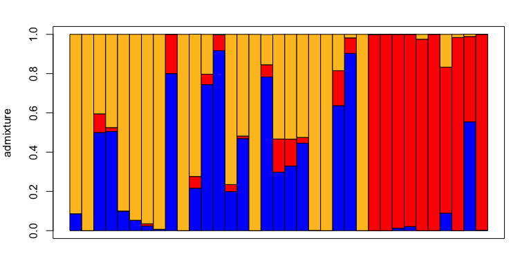

```r
# make a STRUCTURE plot using the
#   maximum a posteriori (MAP) estimates
#   from the first chain of a conStruct run

make.structure.plot(admix.proportions = admix.props)
```

#### Order STRUCTURE plots

The function also includes a variety of options for tweaking the order of the plotted samples.

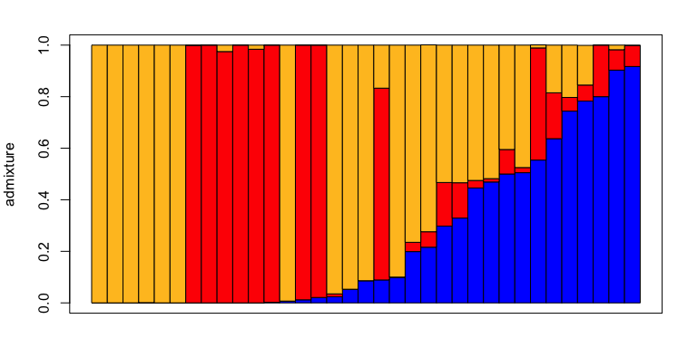

```r
# order by membership in layer 1
make.structure.plot(admix.proportions = admix.props,
                    sort.by = 1)
```

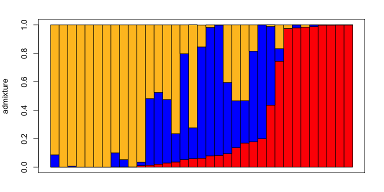

```r
# re-order the stacking order of the layers
make.structure.plot(admix.proportions = admix.props,
                    layer.order = c(2,1,3),
                    sort.by = 2)
```

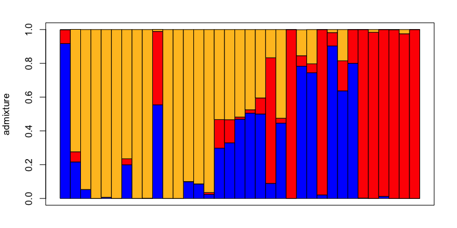

```r
# provide a custom sample ordering
#   in this case by sample latitude
make.structure.plot(admix.proportions = admix.props,
                    sample.order = order(data.block$coords[,2]))
```

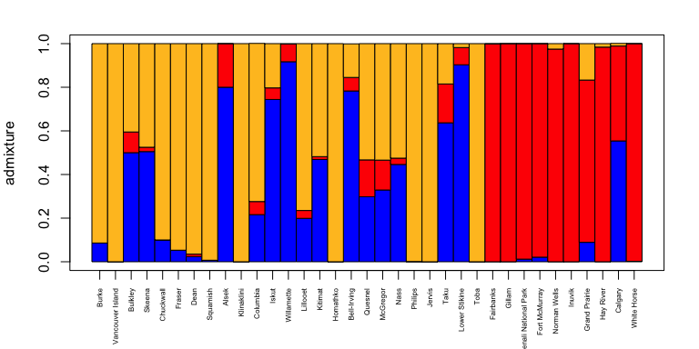

```r
# add sample names
make.structure.plot(admix.proportions = admix.props,
                    sample.names = row.names(data.block$coords),
                    mar = c(4.5,4,2,2))
```

### ADMIXTURE pie plots

It is often also useful to visualize estimated admixture proportions in a spatial context by plotting them on a map. The most common way to do this is to plot a pie plot at the sampling location of each sample, in which each modeled layer gets its own slice of the pie (`K` wedges), and the size of each slice in the pie is proportional to the sample’s admixture proportion in that layer.

Users can make an admixture pie plot with their own data using the command `make.admix.pie.plot` (see documentation at `help(make.admix.pie.plot)`. This function takes as its principal arguments the estimated admixture proportions and the sample coordinates, then makes an admixture pie plot in the plotting window. An example is given below:

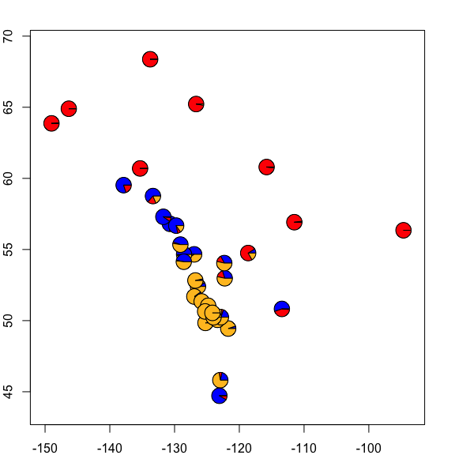

```r
# make an admix pie plot using the
#   maximum a posteriori (MAP) estimates
#   from the first chain of a conStruct run
    make.admix.pie.plot(admix.proportions = admix.props,
                        coords = data.block$coords)
```

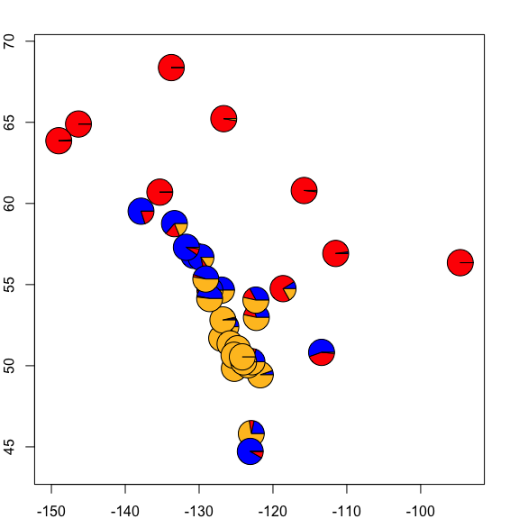

```r
# increase pie chart size
    make.admix.pie.plot(admix.proportions = admix.props,
                        coords = data.block$coords,
                        radii = 4)
```

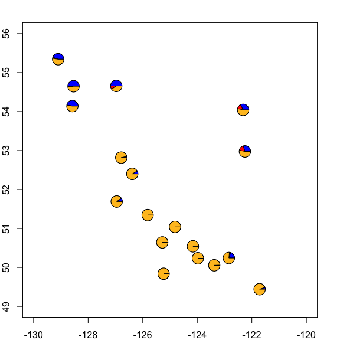

```r
# zoom in on a subsection of the map
    make.admix.pie.plot(admix.proportions = admix.props,
                        coords = data.block$coords,
                        x.lim = c(-130,-120),
                        y.lim = c(49,56))
```

#### Pie plot on a map

Users can also add the pie plot directly to a map of their own creation using the `make.admix.pie.plot` by setting the `add` argument to `TRUE`. E.g.,

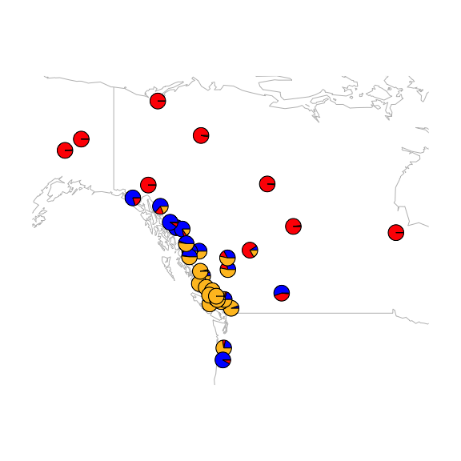

```r
# add pie plot to an existing map

# make the desired map
    maps::map(xlim = range(data.block$coords[,1]) + c(-5,5), ylim = range(data.block$coords[,2])+c(-2,2), col="gray")

# add the admixture pie plot
    make.admix.pie.plot(admix.proportions = admix.props,
                        coords = data.block$coords,
                        add = TRUE)
```

## Comparing two conStruct runs

If you’ve run multiple `conStruct` analyses you may want to visually compare them. Although you could always just open up both sets of output pdfs, label-switching between independent runs can make visual comparisons difficult. Label-switching different models have the same, or very similar, estimated admixture proportions, but with a different permutation of layer labels (e.g., Layer 1 in run 1, and Layer 3 in run 2). To enable easy comparison between a pair of `conStruct` runs, you can use the function `compare.two.runs`.

```r
# load output files from a run with
#   the spatial model and K=4
load("spK4.conStruct.results.Robj")
load("spK4.data.block.Robj")

# assign to new variable names
spK4_cr <- conStruct.results
spK4_db <- data.block

# load output files from a run with
#   the spatial model and K=3
load("spK3.conStruct.results.Robj")
load("spK3.data.block.Robj")

# assign to new variable names
spK3_cr <- conStruct.results
spK3_db <- data.block

# compare the two runs
compare.two.runs(conStruct.results1=spK3_cr,
                 data.block1=spK3_db,
                 conStruct.results2=spK4_cr,
                 data.block2=spK4_db,
                 prefix="spK3_vs_spK4")

# generates a bunch of pdf figures
```